# SLMD - Final Class Lab

# Clustering

## K-means

The k-means algorithm is provided in the `class` package and the function is nammed `kmeans`.

```r
library(class)
?kmeans
```

```
## starting httpd help server ... done
```

```r
out = kmeans(X[ ,-5],3, nstart= 10)
out
```

```
## K-means clustering with 3 clusters of sizes 50, 62, 38
##
## Cluster means:
##   Sepal.Length Sepal.Width Petal.Length Petal.Width
## 1     5.006000    3.428000     1.462000    0.246000
## 2     5.901613    2.748387     4.393548    1.433871
## 3     6.850000    3.073684     5.742105    2.071053
##
## Clustering vector:
##   [1] 1 1 1 1 1 1 1 1 1 1 1 1 1 1 1 1 1 1 1 1 1 1 1 1 1 1 1 1 1 1 1 1 1 1 1
##  [36] 1 1 1 1 1 1 1 1 1 1 1 1 1 1 1 2 2 3 2 2 2 2 2 2 2 2 2 2 2 2 2 2 2 2 2
##  [71] 2 2 2 2 2 2 2 3 2 2 2 2 2 2 2 2 2 2 2 2 2 2 2 2 2 2 2 2 2 2 3 2 3 3 3
## [106] 3 2 3 3 3 3 3 3 2 2 3 3 3 3 2 3 2 3 2 3 3 2 2 3 3 3 3 3 2 3 3 3 3 2 3
## [141] 3 3 2 3 3 3 2 3 3 2
##
## Within cluster sum of squares by cluster:
## [1] 15.15100 39.82097 23.87947
##  (between_SS / total_SS =  88.4 %)
##
## Available components:
##
## [1] "cluster"      "centers"      "totss"        "withinss"
## [5] "tot.withinss" "betweenss"    "size"         "iter"
## [9] "ifault"
```

Let’s try now to find the most appropriate numeber of groups:

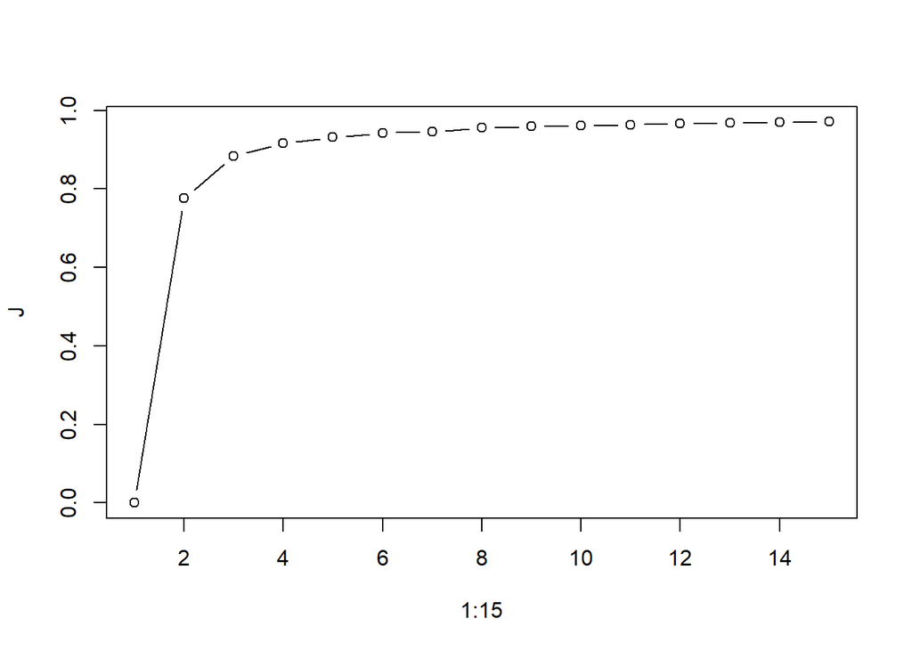

```r
J = c()
for (k in 1:15){
  out = kmeans(X[,-5],k,nstart=15)
  J[k] = out$betweenss / out$totss
}
plot(1:15,J,type='b')
```

Here, we should choose either 3 or 4 groups.

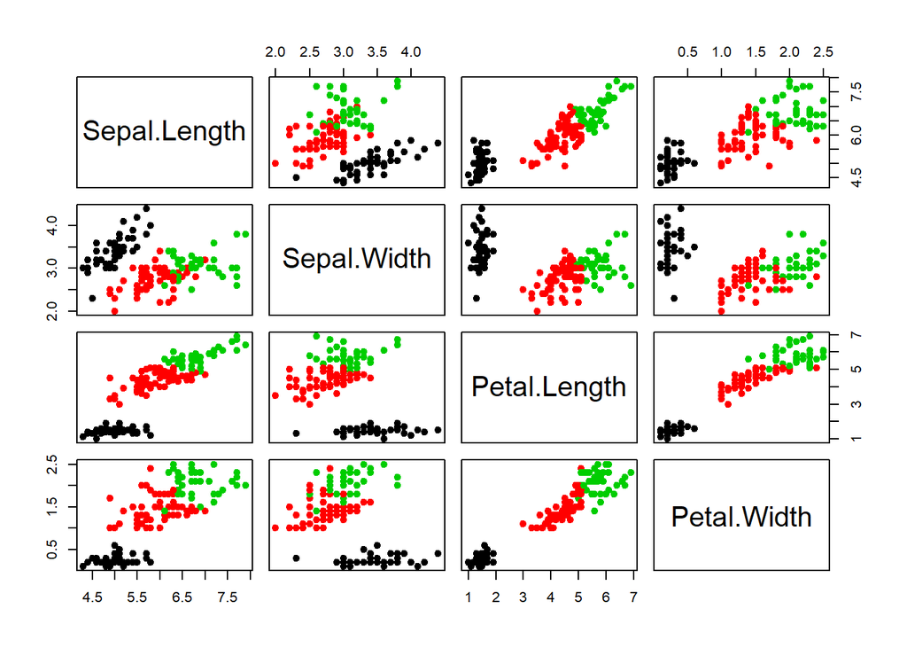

```r
out = kmeans(X[,-5],3)
pairs(X[,-5],col=out$cluster,pch=19)
```

> Exercise: use the k-means algorithm to cluster the `swiss` data

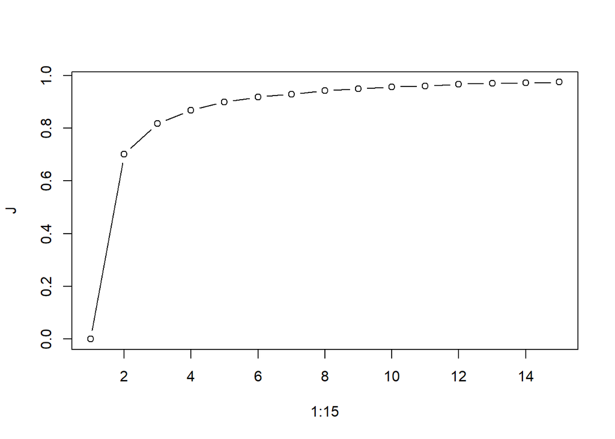

```r
data(swiss)

J = c()
for (k in 1:15){
  out = kmeans(swiss,k,nstart=15)
  J[k] = out$betweenss / out$totss
}
plot(1:15,J,type='b')
```

```r
out = kmeans(swiss,5,nstart=15)
out
```

```
## K-means clustering with 5 clusters of sizes 6, 10, 16, 12, 3
##
## Cluster means:
##   Fertility Agriculture Examination Education Catholic Infant.Mortality
## 1  74.96667    83.20000     6.50000  4.666667 99.47833         17.78333
## 2  83.90000    54.91000    11.20000  7.800000 94.15300         22.57000
## 3  66.31250    60.72500    16.93750  7.687500  6.45875         19.55000
## 4  68.70000    23.80000    23.16667 14.666667 11.74333         19.71667
## 5  40.83333    25.16667    25.00000 37.000000 50.36667         18.50000
##
## Clustering vector:
##   Courtelary     Delemont Franches-Mnt      Moutier   Neuveville
##            4            2            2            4            3
##   Porrentruy        Broye        Glane      Gruyere       Sarine
##            2            2            2            2            2
##      Veveyse        Aigle      Aubonne     Avenches     Cossonay
##            2            3            3            3            3
##    Echallens     Grandson     Lausanne    La Vallee       Lavaux
##            3            4            4            4            3
##       Morges       Moudon        Nyone         Orbe         Oron
##            3            3            3            3            3
##      Payerne Paysd'enhaut        Rolle        Vevey      Yverdon
##            3            3            3            4            3
##      Conthey    Entremont       Herens     Martigwy      Monthey
##            1            1            1            1            2
##   St Maurice       Sierre         Sion       Boudry La Chauxdfnd
##            1            1            2            4            4
##     Le Locle    Neuchatel   Val de Ruz ValdeTravers V. De Geneve
##            4            4            4            4            5
##  Rive Droite  Rive Gauche
##            5            5
##
## Within cluster sum of squares by cluster:
## [1]  706.7855 2213.7172 2759.4449 4490.2569 1839.8794
##  (between_SS / total_SS =  89.9 %)
##
## Available components:
##
## [1] "cluster"      "centers"      "totss"        "withinss"
## [5] "tot.withinss" "betweenss"    "size"         "iter"
## [9] "ifault"
```

If we would like to make the choice of K automatic, we may implement the following:

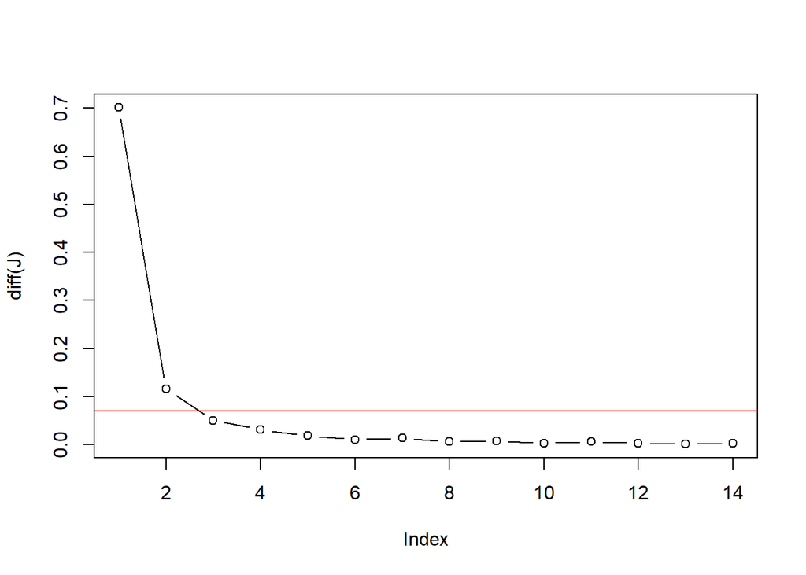

```r
thd = 0.1
plot(diff(J),type='b')
abline(h = thd*max(diff(J)),col='red')
```

```r
Kstar = max(which(diff(J) >=  thd*max(diff(J)))) + 1
Kstar
```

```
## [1] 3
```

## The hierarchical clustering

This method is implemented in R within the `class` package and the appriopriate method is named `hclust`.

> Exercise: cluster the `swiss` data with `hclust`.

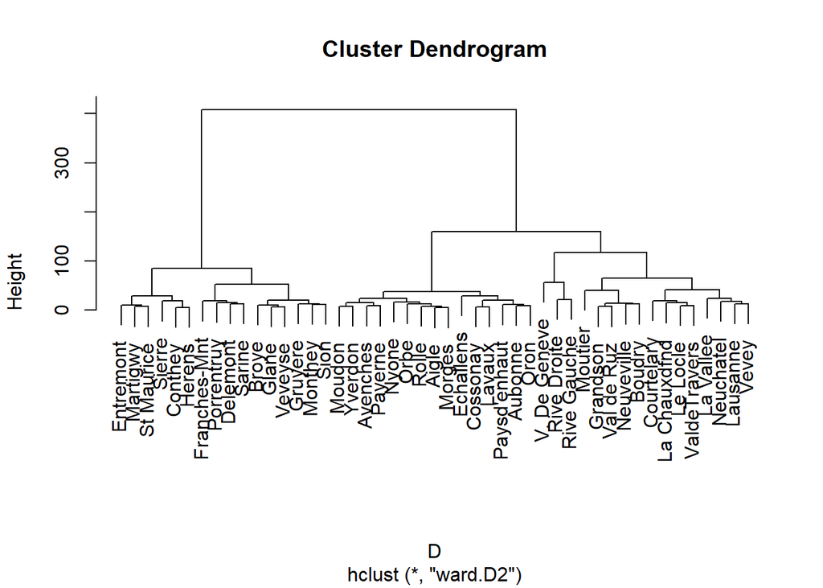

```r
data(swiss)

D = dist(swiss)
out = hclust(D,method = "ward.D2")

plot(out)
```

[figure not shown]

```r
par(mfrow=c(2,2))
out = hclust(D,method = "single"); plot(out)
out = hclust(D,method = "complete"); plot(out)
out = hclust(D,method = "centroid"); plot(out)
out = hclust(D,method = "ward.D2"); plot(out)
```

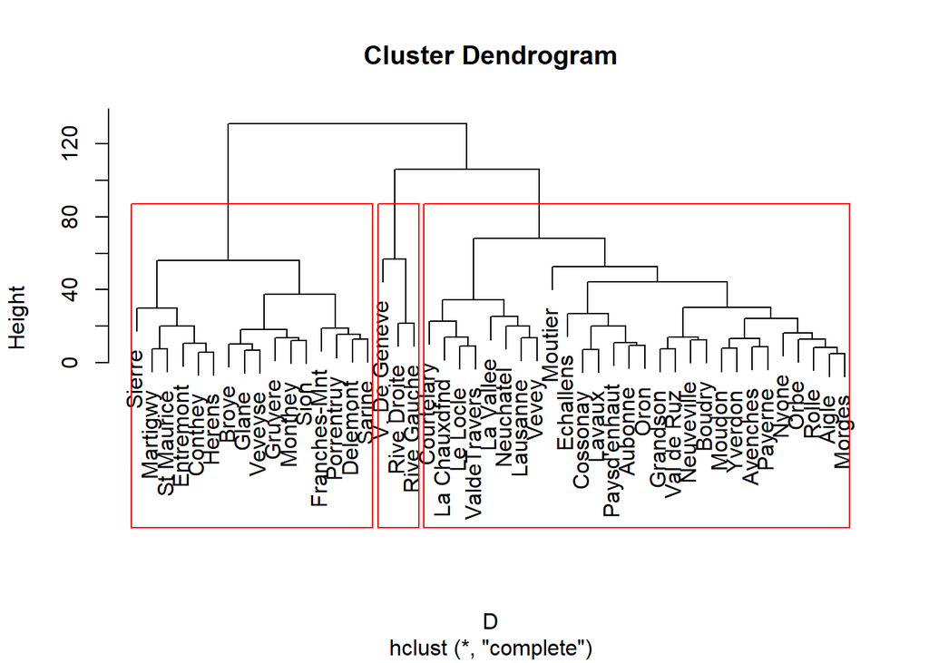

```r
out1 = hclust(D,method = "complete")
plot(out1)
K1 = 3
res1 = cutree(out1, K1)
rect.hclust(out1,K1)
```

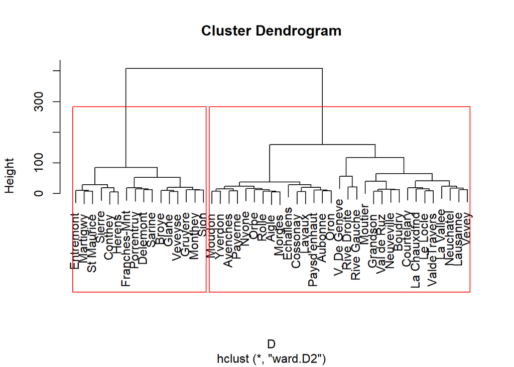

```r
out2 = hclust(D,method = "ward.D2")
plot(out2)
K2 = 2
res2 = cutree(out2, K2)
rect.hclust(out2,K2)
```

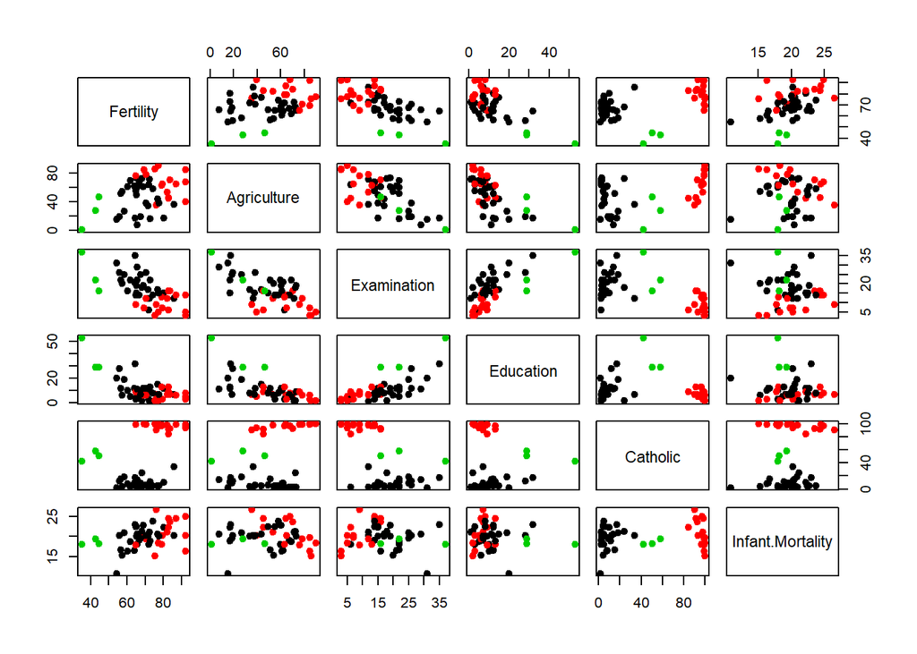

```r
pairs(swiss,col = res1, pch=19)
```

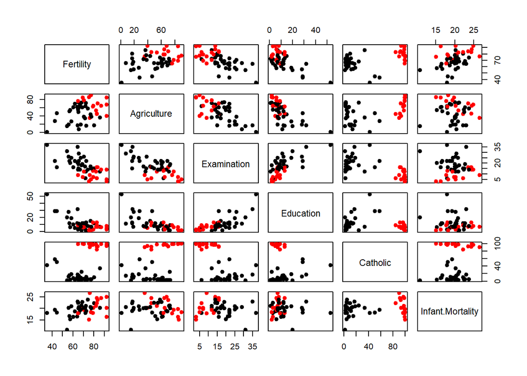

```r
pairs(swiss,col = res2, pch=19)
```

## The Mixture model and the EM algorithm

The `mclust` package (Raftery et al.) allows to cluster some datat with GMM and the EM algorithm.

```r
#install.packages('mclust')
library(mclust)
```

```r
data(swiss)
out = Mclust(swiss,G = 2:10)
#plot(out)
```

```r
out$modelName
```

```
## [1] "EEE"
```

```r
out$parameters$mean
```

```
##                       [,1]     [,2]     [,3]
## Fertility        67.335714 80.55000 40.83333
## Agriculture      44.900000 65.51875 25.16667
## Examination      19.607143  9.43750 25.00000
## Education        10.678571  6.62500 37.00000
## Catholic          8.723571 96.15000 50.36667
## Infant.Mortality 19.621429 20.77500 18.50000
```

```r
out$parameters$pro
```

```
## [1] 0.59574468 0.34042553 0.06382979
```

```r
out$parameters$variance
```

```
## $modelName
## [1] "EEE"
##
## $d
## [1] 6
##
## $G
## [1] 3
##
## $sigma
## , , 1
##
##                   Fertility Agriculture Examination    Education
## Fertility         56.324063  -11.930674 -16.8778115 -14.42933131
## Agriculture      -11.930674  368.415980 -61.5283245 -73.35079786
## Examination      -16.877812  -61.528324  34.9492781  28.40615501
## Education        -14.429331  -73.350798  28.4061550  40.76291793
## Catholic           4.581123   -2.658348   0.7508359   0.02387538
## Infant.Mortality   8.648693  -11.600266   0.7853343   0.84984802
##                     Catholic Infant.Mortality
## Fertility         4.58112258        8.6486930
## Agriculture      -2.65834751      -11.6002660
## Examination       0.75083587        0.7853343
## Education         0.02387538        0.8498480
## Catholic         40.66932150       -0.0764924
## Infant.Mortality -0.07649240        7.8731307
##
## , , 2
##
##                   Fertility Agriculture Examination    Education
## Fertility         56.324063  -11.930674 -16.8778115 -14.42933131
## Agriculture      -11.930674  368.415980 -61.5283245 -73.35079786
## Examination      -16.877812  -61.528324  34.9492781  28.40615501
## Education        -14.429331  -73.350798  28.4061550  40.76291793
## Catholic           4.581123   -2.658348   0.7508359   0.02387538
## Infant.Mortality   8.648693  -11.600266   0.7853343   0.84984802
##                     Catholic Infant.Mortality
## Fertility         4.58112258        8.6486930
## Agriculture      -2.65834751      -11.6002660
## Examination       0.75083587        0.7853343
```

[output cut: 38 more lines]

```
## $cholSigma
##                  Fertility Agriculture Examination Education    Catholic
## Fertility         7.504936    -1.58971   -2.248895 -1.922646  0.61041462
## Agriculture       0.000000    19.12822   -3.403527 -3.994478 -0.08824476
## Examination       0.000000     0.00000   -4.278756 -2.450949 -0.42611701
## Education         0.000000     0.00000    0.000000 -3.886303  0.05130754
## Catholic          0.000000     0.00000    0.000000  0.000000 -6.33282877
## Infant.Mortality  0.000000     0.00000    0.000000  0.000000  0.00000000
##                  Infant.Mortality
## Fertility              1.15240065
## Agriculture           -0.51067390
## Examination           -0.38302481
## Education             -0.02234927
## Catholic               0.15586488
## Infant.Mortality      -2.47241061
```

The `Rmixmod` package also allows to use the GGM + EM:

```r
#install.packages('Rmixmod')
library(Rmixmod)
```

```r
out = mixmodCluster(swiss,2:10)
# plot(out)
```

# Dimension reduction

## Principal component analysis (PCA)

Let’s first try to code PCA:

```r
myPCA <- function(X,d=2){
  # Covariance estimation
  Xbar = scale(X,center=TRUE,scale=FALSE)
  Sigma = 1/nrow(Xbar) * t(Xbar) %*% Xbar

  # Eigen-decomposition
  out = eigen(Sigma)

  # Return the PC axes and plot the projection
  U = out$vectors[,1:d]
  Xproj = as.matrix(X) %*% U
  if (d <= 2) plot(Xproj,type='p',pch=19)
  else pairs(Xproj,pch=19)
  return(list(U=U,lambda=out$values))
}
```

Let’s try it on some data:

```r
data(swiss)
U = myPCA(swiss,d=2)
```

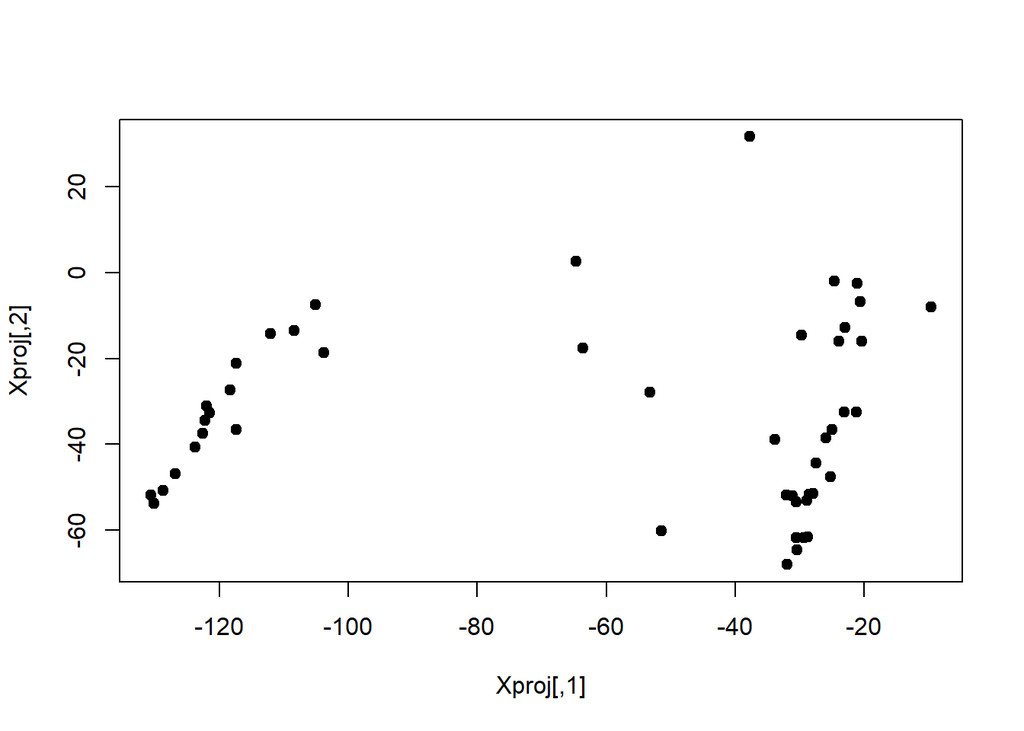

If we use the R function `princomp`:

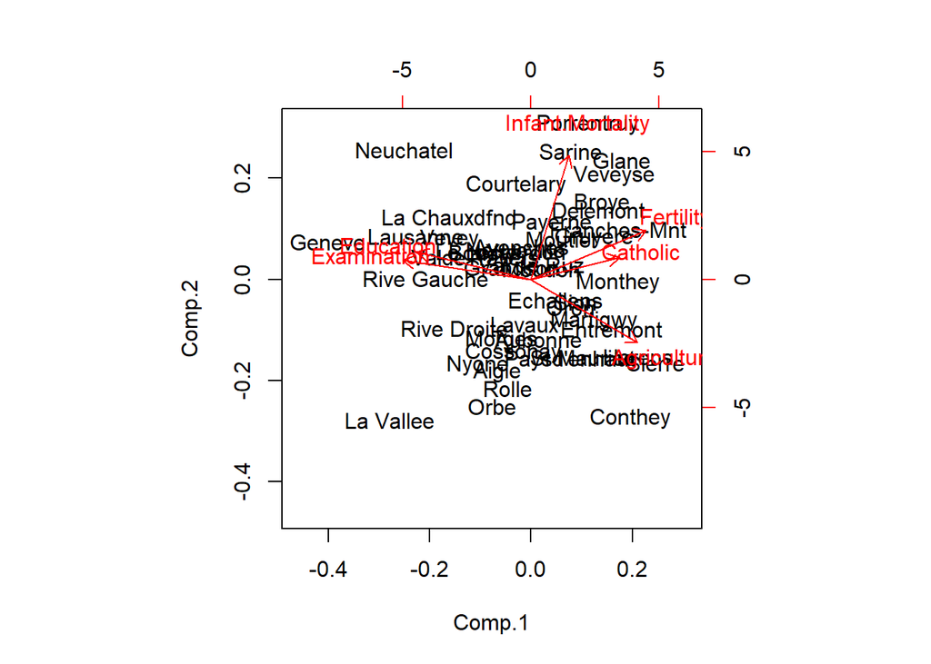

```r
out = princomp(swiss,cor=TRUE)
Xproj = predict(out,swiss)
biplot(out)
```

In the `FactoMineR` package, several additional visulaisations are possible:

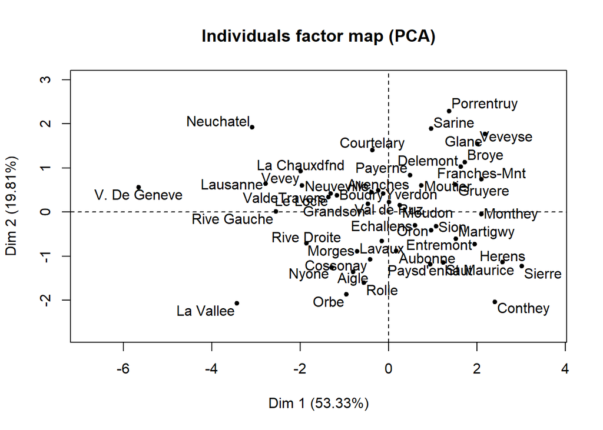

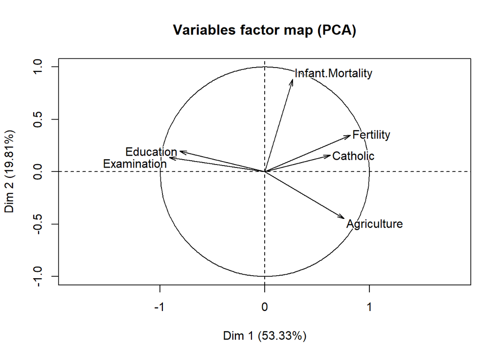

```r
#install.packages('FactoMineR')
library(FactoMineR)
out = PCA(swiss)
```

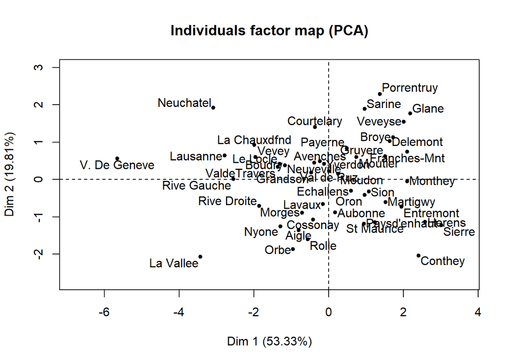

```r
plot(out)
```

> Exercise: use the three methods we saw in class for choosing the right number of components to retain.

```r
out = princomp(swiss)
out$sdev
```

```
##    Comp.1    Comp.2    Comp.3    Comp.4    Comp.5    Comp.6
## 43.366787 21.371202 11.924498  4.708259  3.618425  2.461609
```

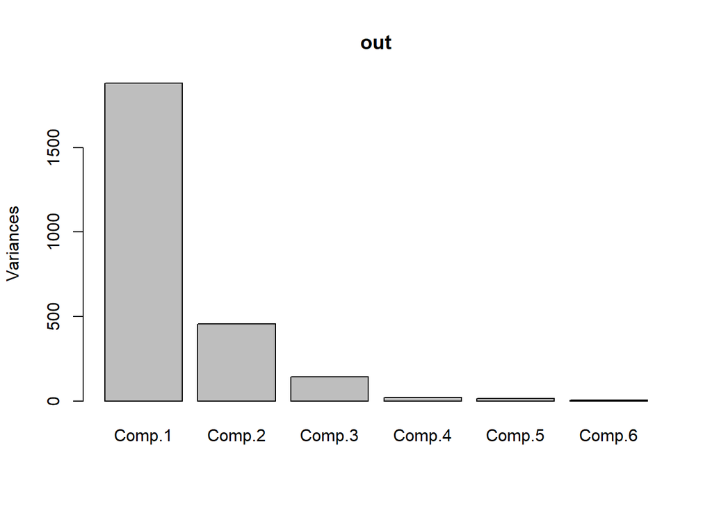

```r
plot(out)
```

```r
summary(out)
```

```
## Importance of components:
##                            Comp.1     Comp.2      Comp.3      Comp.4
## Standard deviation     43.3667866 21.3712016 11.92449843 4.708258751
## Proportion of Variance  0.7460284  0.1811752  0.05640546 0.008793495
## Cumulative Proportion   0.7460284  0.9272036  0.98360907 0.992402568
##                             Comp.5      Comp.6
## Standard deviation     3.618425207 2.461609258
## Proportion of Variance 0.005193739 0.002403694
## Cumulative Proportion  0.997596306 1.000000000
```

The cattell’s test:

```r
out = myPCA(swiss)
```

[figure not shown]

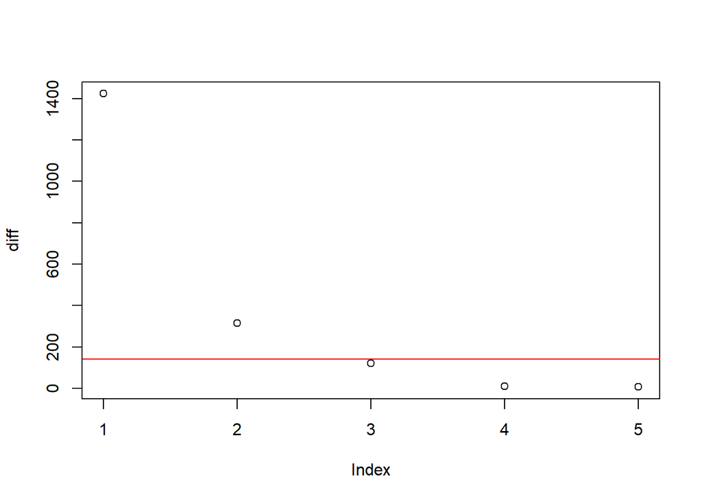

```r
diff = abs(diff(out$lambda))
plot(diff)
abline(h=0.1*max(diff),col='red')
```

Comparision between PCA and scaled PCA:

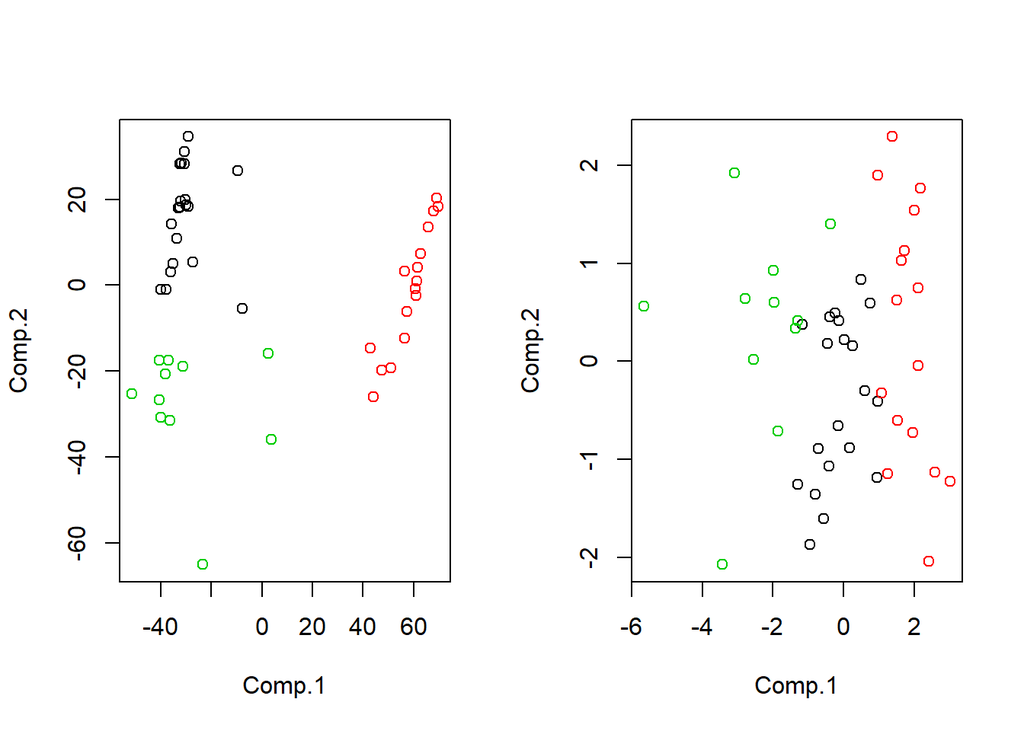

```r
out1 = princomp(swiss)
out2 = princomp(swiss,cor=TRUE)

clus = kmeans(swiss,3)

par(mfrow=c(1,2))
plot(predict(out1,swiss),col=clus$cluster)
plot(predict(out2,swiss),col=clus$cluster)
```

## MDS

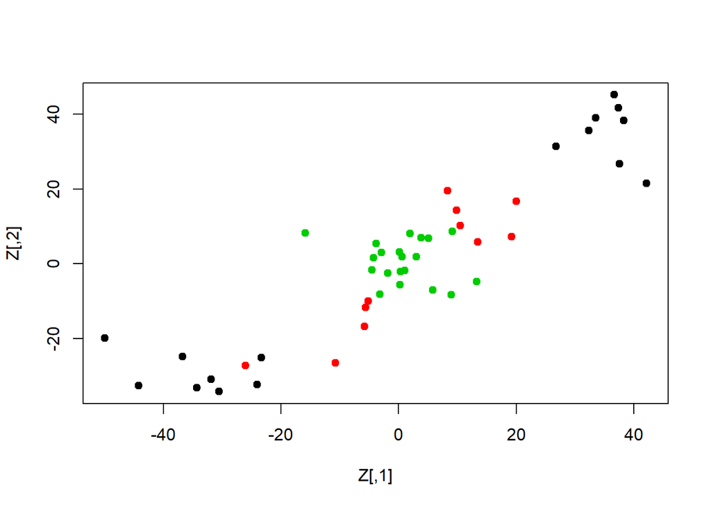

```r
myMDS <- function(X,d=2){
  n= nrow(X); p = ncol(X)
  D = as.matrix(dist(X))
  fun <- function(par,D){
    Z = matrix(par,ncol=d)
    s = 0
    for (i in 1:n){
      for (j in 1:n){
        s = s +
          (D[i,j] - sqrt(sum(Z[i,] - Z[j,])^2))^2
      }
    }
    s
  }
  Zstart = runif(n*d)
  out = optim(Zstart,fun,D = D,method = 'SANN')
  Z = matrix(out$par,ncol=d)
}

Z = myMDS(swiss,d=2)
clus = kmeans(swiss,3)
plot(Z,type='p',pch=19,col=clus$cluster)
```

It is also possible to use the `cmdscale` function of R:

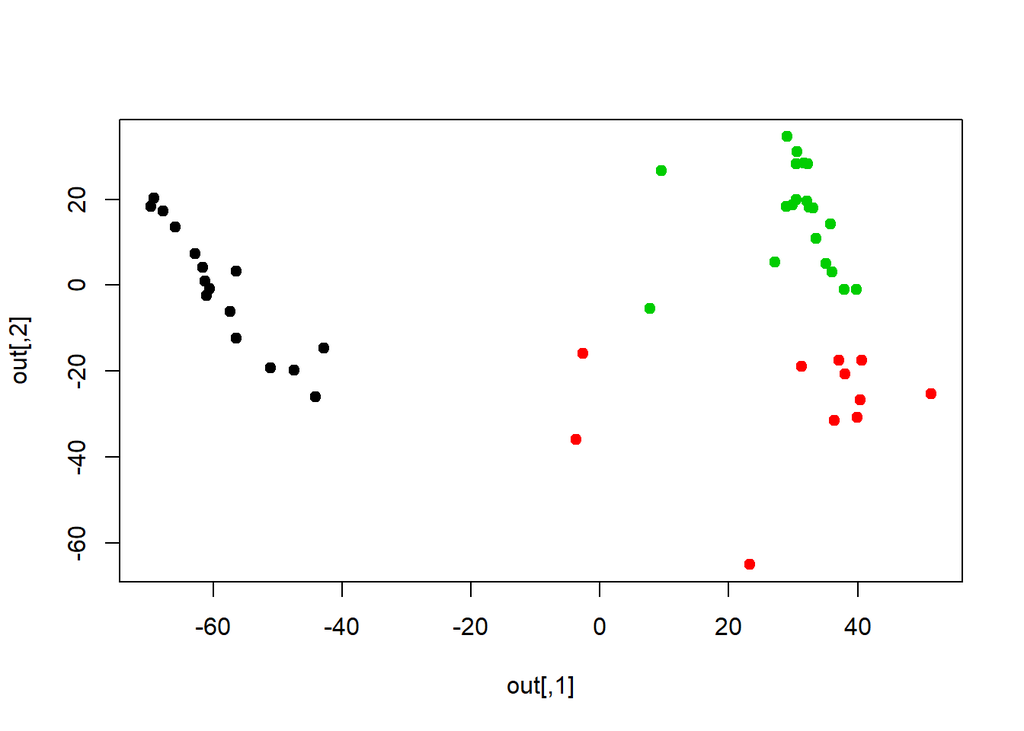

```r
out = cmdscale(dist(swiss),2)
plot(out,type='p',pch=19,col=clus$cluster)
```

# The general procedure

Let’s consider some classification problem with the iris data.

```r
library(MASS); library(class); library(e1071)
X = iris[,-5]
Y = iris[,5]

# I would like to compare several classification techniques (LDA, KNN, SVM)
E = matrix(NA,3,nrow(X))
for(b in 1:nrow(X)){ # Leave-one-out
  Xl = X[-b,]; Yl = Y[-b]
  Xv = X[b,]; Yv = Y[b]

  y1 = predict(lda(Xl,Yl),Xv)
  y2 = knn(Xl,Xv,Yl,k = 5)
  y3 = predict(svm(Xl,Yl,kernel='radial',gamma = 0.05),Xv)

  E[1,b] = as.numeric(y1$class != Yv)
  E[2,b] = as.numeric(y2 != Yv)
  E[3,b] = as.numeric(y3 != Yv)
}

# Pick the most apprpariate method
apply(E,1,mean)
```

```
## [1] 0.02000000 0.03333333 0.04000000
```

```r
apply(E,1,sd)
```

```
## [1] 0.1404690 0.1801069 0.1966157
```

```r
# We finally pick LDA
clf = lda(X,Y)

# in the future...
xstar = c(0.5,8,56,4)
predict(clf,xstar)
```

```
## $class
## [1] virginica
## Levels: setosa versicolor virginica
##
## $posterior
##      setosa    versicolor virginica
## [1,]      0 9.493336e-184         1
##
## $x
##            LD1       LD2
## [1,] -119.7141 -30.16409
```

# Learning in high-dimensional spaces

## The curs of dimensionality

The volume of the hyper-sphere is $V(p) = \frac{\pi^{p/2}}{\Gamma(p/2+1)}$.

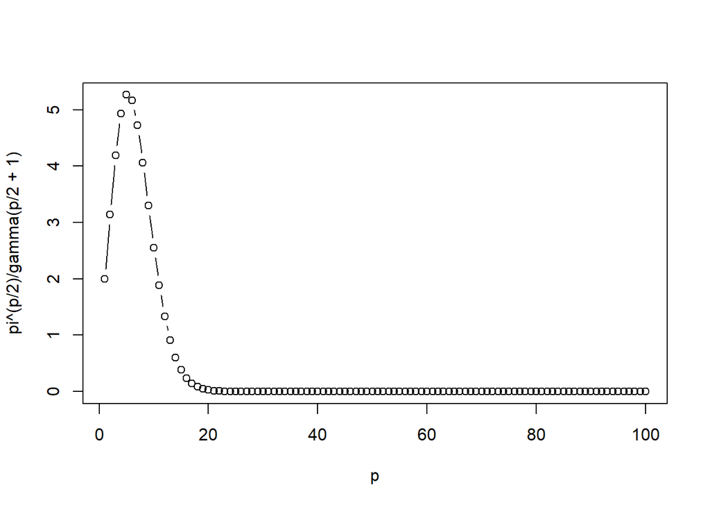

```r
p = 1:100
plot(p,pi^(p/2) / gamma(p/2+1), type='b')
```

## High-dimensional data clustering (HDDC)

HDDC is implemented in the `HDclassif` library (which also p^roposes the HDDA method for classification).

```r
#install.packages('HDclassif')
library(HDclassif)
?hddc
```

We may try HHDC on the wine data set:

```r
data(wine)
X = scale(wine[,-1])
Y = wine$class

out = hddc(X,K=1:10,threshold = (1:10)/100)
```

[output not shown]

```
## HDDC:
##         model  K threshold       BIC
## 1   AKJBKQKDK  2      0.10 -5,580.50
## 2   AKJBKQKDK  2      0.07 -5,603.75
## 3   AKJBKQKDK  2      0.06 -5,603.75
## 4   AKJBKQKDK  2      0.08 -5,603.75
## 5   AKJBKQKDK  2      0.09 -5,603.75
## 6   AKJBKQKDK  2      0.01 -5,605.67
## 7   AKJBKQKDK  2      0.03 -5,605.67
## 8   AKJBKQKDK  2      0.05 -5,621.82
## 9   AKJBKQKDK  2      0.04 -5,630.65
## 10  AKJBKQKDK  2      0.02 -5,653.92
## 11  AKJBKQKDK  1      0.03 -5,705.32
## 12  AKJBKQKDK  1      0.04 -5,705.32
## 13  AKJBKQKDK  1      0.05 -5,705.32
```

[output cut: 90 more lines]

Comparison with Mclust

```r
library(mclust)
out1 = hddc(X,K=3)
```

```
##       model K threshold       BIC
## 1 AKJBKQKDK 3       0.2 -5,608.69
##
## SELECTED: model  AKJBKQKDK  with  3  clusters.
## Selection Criterion: BIC.
```

```r
table(out1$cl,Y)
```

```
##    Y
##      1  2  3
##   1  0 69  0
##   2 59  2  0
##   3  0  0 48
```

```r
out2 = Mclust(X,G=3)
table(out2$cl,Y)
```

```
##    Y
##      1  2  3
##   1 56  0  0
##   2  3 70  0
##   3  0  1 48
```

Let’s now move to higher dimensions:

HDDC (High Dimensional Data Clustering) (GMM is in the code but too slow to finish the job)

```r
#install.packages('MBCbook')
library(MBCbook)
data("usps358")
X = usps358[,-1]
Y = usps358$cls

system.time(out1 <- hddc(X,K=3, threshold = (1:10)/100))
```

```
## HDDC:
##        model K threshold         BIC
## 1  AKJBKQKDK 3      0.01 -424,044.11
## 2  AKJBKQKDK 3      0.02 -434,494.38
## 3  AKJBKQKDK 3      0.03 -477,367.98
## 4  AKJBKQKDK 3      0.04 -499,042.75
## 5  AKJBKQKDK 3      0.06 -499,165.86
## 6  AKJBKQKDK 3      0.08 -506,857.39
## 7  AKJBKQKDK 3      0.05 -515,311.28
## 8  AKJBKQKDK 3      0.07 -525,294.47
## 9  AKJBKQKDK 3      0.09 -536,566.84
## 10 AKJBKQKDK 3      0.10 -536,791.01
##
## SELECTED: model  AKJBKQKDK  with  3  clusters.
## Selection Criterion: BIC.
```

```
##    user  system elapsed
##  173.28    9.06  182.56
```

```r
table(out1$cl,Y)
```

```
##    Y
##       1   2   3
##   1 583  11  33
##   2  33 529  14
##   3  42  16 495
```

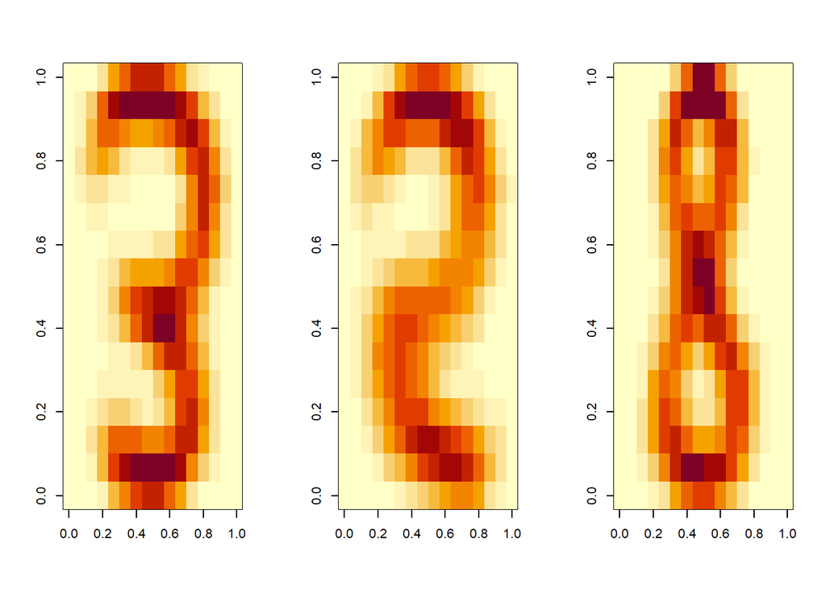

```r
par(mfrow=c(1,3))
image(matrix(out1$mu[1,],ncol=16))
image(matrix(out1$mu[2,],ncol=16))
image(matrix(out1$mu[3,],ncol=16))
```

```r
# system.time(out2 <- Mclust(X,G=3,modelNames = 'VVV'))
# table(out2$cl,Y)
```

```r
out1$d
```

```
##       Intrinsic dimensions of the classes:
##         1  2  3
##   dim: 34 40 33
```

Fisher EM

```r
#install.packages('FisherEM')
library(FisherEM)
system.time(out2 <- fem(X,K=3))
```

```
##    user  system elapsed
##   16.87    1.86   18.78
```

```r
table(out2$cl,Y)
```

```
##    Y
##       1   2   3
##   1  95 517  62
##   2 515   5  18
##   3  48  34 462
```